# Supervised Learning - Foundations Project: ReCell

- EDA double check (after manipulating some data)

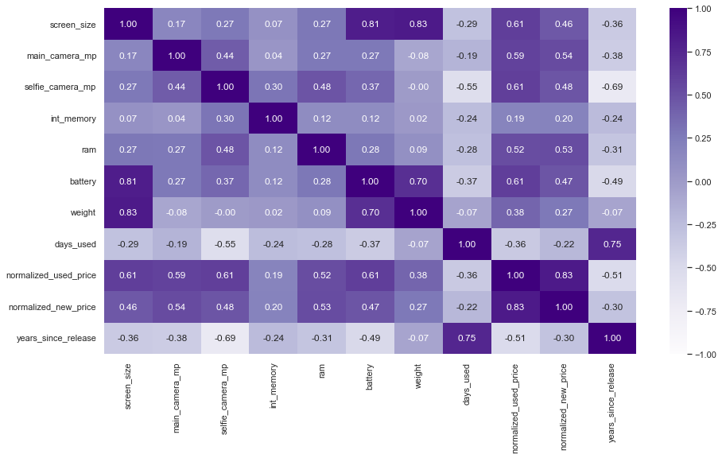

```python
cols2 = df1.select_dtypes(include=np.number).columns.to_list()

plt.figure(figsize=(15,8))
sns.heatmap(df1[cols2].corr(), annot=True, vmin=-1, vmax=1, fmt=".2f", cmap="Purples");
```

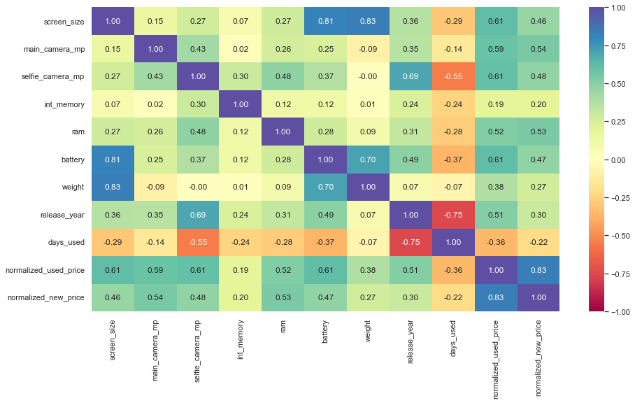

```python
cols = df.select_dtypes(include=np.number).columns.to_list()


plt.figure(figsize=(15,8))
sns.heatmap(df[cols].corr(), annot=True, vmin=-1, vmax=1, fmt=".2f", cmap="Spectral");
```

Correlations remain largely unchanged between df (no processing) and df1 (processed). This gives me enough confidence to move forward with model iteration for df1 knowing that my data is still representative of the original.

- Preparing data for modeling

```python
X = df1.drop(['normalized_used_price'], axis=1)
y = df1['normalized_used_price']
```

```python
X.head()
```

|  | brand_name | os | screen_size | 4g | 5g | main_camera_mp | selfie_camera_mp | int_memory | ram | battery | weight | days_used | normalized_new_price | years_since_release |
| --- | --- | --- | --- | --- | --- | --- | --- | --- | --- | --- | --- | --- | --- | --- |
| 0 | Honor | Android | 14.50 | yes | no | 13.0 | 5.0 | 64.0 | 3.0 | 3020.0 | 146.0 | 127 | 4.715100 | 1 |
| 1 | Honor | Android | 17.30 | yes | yes | 13.0 | 16.0 | 128.0 | 8.0 | 4300.0 | 213.0 | 325 | 5.519018 | 1 |
| 2 | Honor | Android | 16.69 | yes | yes | 13.0 | 8.0 | 128.0 | 8.0 | 4200.0 | 213.0 | 162 | 5.884631 | 1 |
| 3 | Honor | Android | 25.50 | yes | yes | 13.0 | 8.0 | 64.0 | 6.0 | 7250.0 | 480.0 | 345 | 5.630961 | 1 |
| 4 | Honor | Android | 15.32 | yes | no | 13.0 | 8.0 | 64.0 | 3.0 | 5000.0 | 185.0 | 293 | 4.947837 | 1 |

```python
y.head()
```

```
0    4.307572
1    5.162097
2    5.111084
3    5.135387
4    4.389995
Name: normalized_used_price, dtype: float64
```

```python
#Add a constant term to the linear equation
X = sm.add_constant(X)
```

```python
#create dummy variables
X = pd.get_dummies(X,columns=X.select_dtypes(include=['object','category']).columns.tolist(), drop_first=True,)
```

```python
X.head()
```

|  | const | screen_size | main_camera_mp | selfie_camera_mp | int_memory | ram | battery | weight | days_used | normalized_new_price | ... | brand_name_Spice | brand_name_Vivo | brand_name_XOLO | brand_name_Xiaomi | brand_name_ZTE | os_Others | os_Windows | os_iOS | 4g_yes | 5g_yes |
| --- | --- | --- | --- | --- | --- | --- | --- | --- | --- | --- | --- | --- | --- | --- | --- | --- | --- | --- | --- | --- | --- |
| 0 | 1.0 | 14.50 | 13.0 | 5.0 | 64.0 | 3.0 | 3020.0 | 146.0 | 127 | 4.715100 | ... | 0 | 0 | 0 | 0 | 0 | 0 | 0 | 0 | 1 | 0 |
| 1 | 1.0 | 17.30 | 13.0 | 16.0 | 128.0 | 8.0 | 4300.0 | 213.0 | 325 | 5.519018 | ... | 0 | 0 | 0 | 0 | 0 | 0 | 0 | 0 | 1 | 1 |
| 2 | 1.0 | 16.69 | 13.0 | 8.0 | 128.0 | 8.0 | 4200.0 | 213.0 | 162 | 5.884631 | ... | 0 | 0 | 0 | 0 | 0 | 0 | 0 | 0 | 1 | 1 |
| 3 | 1.0 | 25.50 | 13.0 | 8.0 | 64.0 | 6.0 | 7250.0 | 480.0 | 345 | 5.630961 | ... | 0 | 0 | 0 | 0 | 0 | 0 | 0 | 0 | 1 | 1 |
| 4 | 1.0 | 15.32 | 13.0 | 8.0 | 64.0 | 3.0 | 5000.0 | 185.0 | 293 | 4.947837 | ... | 0 | 0 | 0 | 0 | 0 | 0 | 0 | 0 | 1 | 0 |

5 rows × 49 columns

```python
#splitting the data into 70/30 ratio for train/test

x_train, x_test, y_train, y_test = train_test_split(X, y, test_size=0.3, random_state=1)

#test size =.3 indicates we want to keep 30% of the data for testing
#random state denotes how we want the data shuffled
```

```python
x_train.shape[0] # 2417 rows of training data
```

```
2417
```

```python
x_test.shape[0] # 1037 rows of testing data
```

```
1037
```

## Model Building - Linear Regression

```python
olsmodel1 = sm.OLS(y_train, x_train).fit()
print(olsmodel1.summary())
```

```
                              OLS Regression Results
=================================================================================
Dep. Variable:     normalized_used_price   R-squared:                       0.845
Model:                               OLS   Adj. R-squared:                  0.842
Method:                    Least Squares   F-statistic:                     268.8
Date:                   Fri, 08 Jul 2022   Prob (F-statistic):               0.00
Time:                           14:33:27   Log-Likelihood:                 124.15
No. Observations:                   2417   AIC:                            -150.3
Df Residuals:                       2368   BIC:                             133.4
Df Model:                             48
Covariance Type:               nonrobust
=========================================================================================
                            coef    std err          t      P>|t|      [0.025      0.975]
-----------------------------------------------------------------------------------------
const                     1.3158      0.071     18.461      0.000       1.176       1.456
screen_size               0.0244      0.003      7.156      0.000       0.018       0.031
main_camera_mp            0.0208      0.002     13.848      0.000       0.018       0.024
selfie_camera_mp          0.0135      0.001     11.996      0.000       0.011       0.016
int_memory                0.0001   6.97e-05      1.664      0.096   -2.07e-05       0.000
ram                       0.0232      0.005      4.515      0.000       0.013       0.033
battery               -1.686e-05   7.27e-06     -2.318      0.021   -3.11e-05    -2.6e-06
weight                    0.0010      0.000      7.488      0.000       0.001       0.001
days_used              4.196e-05   3.09e-05      1.360      0.174   -1.85e-05       0.000
normalized_new_price      0.4309      0.012     35.134      0.000       0.407       0.455
years_since_release      -0.0236      0.005     -5.189      0.000      -0.033      -0.015
brand_name_Alcatel        0.0154      0.048      0.324      0.746      -0.078       0.109
brand_name_Apple         -0.0032      0.147     -0.021      0.983      -0.292       0.285
brand_name_Asus           0.0150      0.048      0.313      0.754      -0.079       0.109
brand_name_BlackBerry    -0.0297      0.070     -0.423      0.672      -0.167       0.108
brand_name_Celkon        -0.0463      0.066     -0.699      0.484      -0.176       0.084
brand_name_Coolpad        0.0209      0.073      0.286      0.775      -0.122       0.164
brand_name_Gionee         0.0447      0.058      0.775      0.438      -0.068       0.158
brand_name_Google        -0.0327      0.085     -0.386      0.700      -0.199       0.133
brand_name_HTC           -0.0131      0.048     -0.271      0.786      -0.108       0.081
brand_name_Honor          0.0316      0.049      0.642      0.521      -0.065       0.128
brand_name_Huawei        -0.0022      0.044     -0.049      0.961      -0.089       0.085
brand_name_Infinix        0.1634      0.093      1.753      0.080      -0.019       0.346
brand_name_Karbonn        0.0943      0.067      1.406      0.160      -0.037       0.226
brand_name_LG            -0.0132      0.045     -0.292      0.771      -0.102       0.076
brand_name_Lava           0.0332      0.062      0.533      0.594      -0.089       0.155
```

[output cut: 19 more lines]

```
os_Windows               -0.0202      0.045     -0.448      0.654      -0.109       0.068
os_iOS                   -0.0669      0.146     -0.457      0.648      -0.354       0.220
4g_yes                    0.0530      0.016      3.341      0.001       0.022       0.084
5g_yes                   -0.0721      0.031     -2.292      0.022      -0.134      -0.010
==============================================================================
Omnibus:                      223.220   Durbin-Watson:                   1.911
Prob(Omnibus):                  0.000   Jarque-Bera (JB):              422.514
Skew:                          -0.618   Prob(JB):                     1.79e-92
Kurtosis:                       4.633   Cond. No.                     1.78e+05
==============================================================================

Notes:
[1] Standard Errors assume that the covariance matrix of the errors is correctly specified.
[2] The condition number is large, 1.78e+05. This might indicate that there are
strong multicollinearity or other numerical problems.
```

After running the first model, the Rsquared and adj-Rsquared both explain over 80% of the data. We can feel good about moving forward with this model to make statistical inferances after a few iterations. However, we need to first ensure that the linear regression assumptions are satisfied.

## Model Performance Check

Below is a suite of performance formulas which will help us gauge the effectiveness of our model (RMSE, MAE, R-squared, MAPE, adjusted R-squared)

```python
# adjusted_R_squared calc
def adj_r2_score(predictors, targets, predictions):
    r2 = r2_score(targets, predictions)
    n = predictors.shape[0]
    k = predictors.shape[1]
    return 1 - ((1 - r2) * (n - 1) / (n - k - 1))


# mape
def mape_score(targets, predictions):
    return np.mean(np.abs(targets - predictions) / targets) * 100




def model_performance_regression(model, predictors, target):
    pred = model.predict(predictors)
    r2 = r2_score(target, pred) # r-squared
    adjr2 = adj_r2_score(predictors, target, pred) # adjusted R-squared
    rmse = np.sqrt(mean_squared_error(target, pred)) # RMSE
    mae = mean_absolute_error(target, pred) #MAE
    mape = mape_score(target, pred) #MAPE

    df_perf = pd.DataFrame(
        {
            "RMSE":rmse,
            "MAE":mae,
            "R-squared": r2,
            "Adj. R-squared": adjr2,
            "MAPE": mape,
        },
        index=[0],
    )
    return df_perf
```

```python
# model performance on training set (70% total data)
print("Training Performance\n")
olsmodel_train_perf = model_performance_regression(olsmodel1, x_train, y_train)
olsmodel_train_perf
```

```
Training Performance
```

|  | RMSE | MAE | R-squared | Adj. R-squared | MAPE |
| --- | --- | --- | --- | --- | --- |
| 0 | 0.229856 | 0.180302 | 0.844924 | 0.841713 | 4.326213 |

```python
# model performance on test set (30% total data)
print("Test Performance\n")
olsmodel_test_perf = model_performance_regression(olsmodel1, x_test, y_test)
olsmodel_test_perf
```

```
Test Performance
```

|  | RMSE | MAE | R-squared | Adj. R-squared | MAPE |
| --- | --- | --- | --- | --- | --- |
| 0 | 0.238482 | 0.184868 | 0.842315 | 0.834487 | 4.505694 |

MAPE of 4.5 indicates that our test data can accurately predict normalized used phone prices within 4.5%

RMSE and MAE are nearly identical between test and training data. If our training data had signficantly less error, that would indicate our model was overfitting the training data. That is not an issue in this instance.

Because RMSE uses the squares of residuals, it penalizes the model more for larger errors compared to the MAE metric.

```python
#retrieve predictions from test set
y_pred = olsmodel1.predict(x_test)
```

```python
y_pred
```

```
866     4.220271
957     3.279636
280     4.256035
2150    4.736963
93      4.505120
          ...
2191    4.395813
3217    4.020209
885     2.613920
2991    4.072481
1071    3.859723
Length: 1037, dtype: float64
```

```python
y_test
```

```
866     4.038832
957     2.800325
280     4.370713
2150    4.677863
93      4.517650
          ...
2191    4.697020
3217    3.997099
885     1.536867
2991    4.180828
1071    3.740048
Name: normalized_used_price, Length: 1037, dtype: float64
```

## Checking Linear Regression Assumptions

- In order to make statistical inferences from a linear regression model, it is important to ensure that the assumptions of linear regression are satisfied.
1. No Multicollinearity
1. Linearity of variables
1. independence of error terms
1. Normality of error terms
1. No Heteroscedasticity

1. We will use the VIF test to test our data for multicollinearity

```python
def checking_vif(predictors):
    vif = pd.DataFrame()
    vif['feature'] = predictors.columns

    #calculating for each feature
    vif['VIF'] = [
        variance_inflation_factor(predictors.values, i)
        for i in range(len(predictors.columns))
    ]
    return vif
```

```python
checking_vif(x_train)
```

|  | feature | VIF |
| --- | --- | --- |
| 0 | const | 227.678565 |
| 1 | screen_size | 7.677118 |
| 2 | main_camera_mp | 2.284685 |
| 3 | selfie_camera_mp | 2.810716 |
| 4 | int_memory | 1.364057 |
| 5 | ram | 2.255246 |
| 6 | battery | 4.081715 |
| 7 | weight | 6.397183 |
| 8 | days_used | 2.660002 |
| 9 | normalized_new_price | 3.119569 |
| 10 | years_since_release | 4.898360 |
| 11 | brand_name_Alcatel | 3.405674 |
| 12 | brand_name_Apple | 13.054832 |
| 13 | brand_name_Asus | 3.332003 |
| 14 | brand_name_BlackBerry | 1.632250 |
| 15 | brand_name_Celkon | 1.774820 |
| 16 | brand_name_Coolpad | 1.467981 |
| 17 | brand_name_Gionee | 1.951247 |
| 18 | brand_name_Google | 1.321771 |
| 19 | brand_name_HTC | 3.410252 |
| 20 | brand_name_Honor | 3.340621 |
| 21 | brand_name_Huawei | 5.983857 |
| 22 | brand_name_Infinix | 1.283814 |
| 23 | brand_name_Karbonn | 1.573683 |
| 24 | brand_name_LG | 4.849589 |
| 25 | brand_name_Lava | 1.711317 |
| 26 | brand_name_Lenovo | 4.558847 |
| 27 | brand_name_Meizu | 2.179607 |
| 28 | brand_name_Micromax | 3.363518 |
| 29 | brand_name_Microsoft | 1.869558 |
| 30 | brand_name_Motorola | 3.274455 |
| 31 | brand_name_Nokia | 3.473140 |
| 32 | brand_name_OnePlus | 1.437047 |
| 33 | brand_name_Oppo | 3.971065 |
| 34 | brand_name_Others | 9.710921 |
| 35 | brand_name_Panasonic | 2.105711 |
| 36 | brand_name_Realme | 1.946675 |
| 37 | brand_name_Samsung | 7.539832 |
| 38 | brand_name_Sony | 2.943127 |
| 39 | brand_name_Spice | 1.688868 |
| 40 | brand_name_Vivo | 3.651320 |
| 41 | brand_name_XOLO | 2.138074 |
| 42 | brand_name_Xiaomi | 3.719678 |
| 43 | brand_name_ZTE | 3.797527 |
| 44 | os_Others | 1.854134 |
| 45 | os_Windows | 1.595291 |
| 46 | os_iOS | 11.780766 |
| 47 | 4g_yes | 2.468374 |
| 48 | 5g_yes | 1.811042 |

Weight and Screen size have a VIF over 5, indicated a high level of multicollinearity. Dummy variables can be ignored.

- Remove multicollinearity by dropping columns with VIF > 5 one by and and measure R-squared and RMSE.
- Drop the variable that makes the least change in adjusted R-squared
- Repeat until all VIF is under 5

```python
def treating_multicollinearity(predictors, target, high_vif_columns):
    adj_r2 = [] #empty lists
    rmse = []

    for cols in high_vif_columns:
        train = predictors.loc[:, ~predictors.columns.str.startswith(cols)] #new training set
        olsmodel = sm.OLS(target, train).fit() #create the model

        adj_r2.append(olsmodel.rsquared_adj)
        rmse.append(np.sqrt(olsmodel.mse_resid))

    temp = pd.DataFrame(
        {
            "col": high_vif_columns,
            "adj. R-squared after_dropping col": adj_r2,
            "RMSE after dropping col": rmse,
        }
    ).sort_values(by="adj. R-squared after_dropping col", ascending=False)
    temp.reset_index(drop=True, inplace=True)

    return temp
```

```python
col_list = [
    "screen_size",
    "weight",
]

res = treating_multicollinearity(x_train, y_train, col_list)
res
```

|  | col | adj. R-squared after_dropping col | RMSE after dropping col |
| --- | --- | --- | --- |
| 0 | screen_size | 0.838427 | 0.234670 |
| 1 | weight | 0.838102 | 0.234906 |

```python
col_to_drop = "screen_size"
x_train2 = x_train.loc[:, ~x_train.columns.str.startswith(col_to_drop)]
x_test2 = x_test.loc[:, ~x_test.columns.str.startswith(col_to_drop)]

#new VIF check
vif = checking_vif(x_train2)
print('VIF after dropping ', col_to_drop)
vif
```

```
VIF after dropping  screen_size
```

|  | feature | VIF |
| --- | --- | --- |
| 0 | const | 202.629212 |
| 1 | main_camera_mp | 2.281449 |
| 2 | selfie_camera_mp | 2.807324 |
| 3 | int_memory | 1.361996 |
| 4 | ram | 2.255245 |
| 5 | battery | 3.842940 |
| 6 | weight | 2.993841 |
| 7 | days_used | 2.648681 |
| 8 | normalized_new_price | 3.078112 |
| 9 | years_since_release | 4.729654 |
| 10 | brand_name_Alcatel | 3.405512 |
| 11 | brand_name_Apple | 12.997673 |
| 12 | brand_name_Asus | 3.326668 |
| 13 | brand_name_BlackBerry | 1.630909 |
| 14 | brand_name_Celkon | 1.774631 |
| 15 | brand_name_Coolpad | 1.467694 |
| 16 | brand_name_Gionee | 1.941421 |
| 17 | brand_name_Google | 1.319330 |
| 18 | brand_name_HTC | 3.399889 |
| 19 | brand_name_Honor | 3.340286 |
| 20 | brand_name_Huawei | 5.981050 |
| 21 | brand_name_Infinix | 1.283390 |
| 22 | brand_name_Karbonn | 1.573475 |
| 23 | brand_name_LG | 4.832342 |
| 24 | brand_name_Lava | 1.711050 |
| 25 | brand_name_Lenovo | 4.553704 |
| 26 | brand_name_Meizu | 2.176424 |
| 27 | brand_name_Micromax | 3.358621 |
| 28 | brand_name_Microsoft | 1.868055 |
| 29 | brand_name_Motorola | 3.262268 |
| 30 | brand_name_Nokia | 3.458040 |
| 31 | brand_name_OnePlus | 1.437017 |
| 32 | brand_name_Oppo | 3.965329 |
| 33 | brand_name_Others | 9.652505 |
| 34 | brand_name_Panasonic | 2.104860 |
| 35 | brand_name_Realme | 1.943720 |
| 36 | brand_name_Samsung | 7.523396 |
| 37 | brand_name_Sony | 2.937348 |
| 38 | brand_name_Spice | 1.683302 |
| 39 | brand_name_Vivo | 3.650512 |
| 40 | brand_name_XOLO | 2.137848 |
| 41 | brand_name_Xiaomi | 3.713977 |
| 42 | brand_name_ZTE | 3.788924 |
| 43 | os_Others | 1.619868 |
| 44 | os_Windows | 1.595196 |
| 45 | os_iOS | 11.675335 |
| 46 | 4g_yes | 2.467616 |
| 47 | 5g_yes | 1.807304 |

Next, we must drop columns with a p-value that is greater than 0.05 because these are not statistically significant (dummy variables in most instances).

Instead of dropping columns with high P-value one by one, we will create a function and iterate over all the columns, dropping the column with the highest P-value and reviewing each time.

We will iterate until there are no columns with a P-value greater than 5.

```python
#initial list of columns
predictors = x_train2.copy()
cols = predictors.columns.tolist()

#setting an inital max p-value
max_p_value = 1

while len(cols) > 0:
    #defining the train set
    x_train_aux = predictors[cols]

    #fit  model
    model = sm.OLS(y_train, x_train_aux).fit()

    #p-value and max p-value
    p_values = model.pvalues
    max_p_value = max(p_values)

    # name of the variable with maximum p-value
    feature_with_p_max = p_values.idxmax()

    if max_p_value > 0.05:
        cols.remove(feature_with_p_max)
    else:
        break


selected_feature = cols
print(selected_feature)
```

```
['const', 'main_camera_mp', 'selfie_camera_mp', 'ram', 'weight', 'normalized_new_price', 'years_since_release', 'brand_name_Karbonn', 'brand_name_Samsung', 'brand_name_Sony', 'brand_name_Xiaomi', 'os_Others', 'os_iOS', '4g_yes', '5g_yes']
```

```python
x_train3 = x_train2[selected_feature]
x_test3 = x_test2[selected_feature]
```

```python
olsmodel2 = sm.OLS(y_train, x_train3).fit()
print(olsmodel2.summary())
```

```
                              OLS Regression Results
=================================================================================
Dep. Variable:     normalized_used_price   R-squared:                       0.839
Model:                               OLS   Adj. R-squared:                  0.838
Method:                    Least Squares   F-statistic:                     896.0
Date:                   Fri, 08 Jul 2022   Prob (F-statistic):               0.00
Time:                           14:33:28   Log-Likelihood:                 81.046
No. Observations:                   2417   AIC:                            -132.1
Df Residuals:                       2402   BIC:                            -45.24
Df Model:                             14
Covariance Type:               nonrobust
========================================================================================
                           coef    std err          t      P>|t|      [0.025      0.975]
----------------------------------------------------------------------------------------
const                    1.4996      0.048     30.951      0.000       1.405       1.595
main_camera_mp           0.0210      0.001     14.716      0.000       0.018       0.024
selfie_camera_mp         0.0138      0.001     12.853      0.000       0.012       0.016
ram                      0.0212      0.005      4.246      0.000       0.011       0.031
weight                   0.0017      6e-05     27.684      0.000       0.002       0.002
normalized_new_price     0.4412      0.011     39.311      0.000       0.419       0.463
years_since_release     -0.0292      0.003     -8.587      0.000      -0.036      -0.022
brand_name_Karbonn       0.1157      0.055      2.114      0.035       0.008       0.223
brand_name_Samsung      -0.0374      0.016     -2.270      0.023      -0.070      -0.005
brand_name_Sony         -0.0670      0.030     -2.197      0.028      -0.127      -0.007
brand_name_Xiaomi        0.0800      0.026      3.113      0.002       0.030       0.130
os_Others               -0.1282      0.027     -4.706      0.000      -0.182      -0.075
os_iOS                  -0.0898      0.045     -1.990      0.047      -0.178      -0.001
4g_yes                   0.0504      0.015      3.340      0.001       0.021       0.080
5g_yes                  -0.0684      0.031     -2.234      0.026      -0.129      -0.008
==============================================================================
Omnibus:                      245.617   Durbin-Watson:                   1.903
Prob(Omnibus):                  0.000   Jarque-Bera (JB):              483.665
Skew:                          -0.656   Prob(JB):                    9.41e-106
Kurtosis:                       4.755   Cond. No.                     2.39e+03
==============================================================================

Notes:
[1] Standard Errors assume that the covariance matrix of the errors is correctly specified.
[2] The condition number is large, 2.39e+03. This might indicate that there are
strong multicollinearity or other numerical problems.
```

We can see now that there are no columns left with a P-value > 0.05

```python
# new model performance on train set
print('Training Performance\n')
olsmodel2_train_perf = model_performance_regression(olsmodel2, x_train3, y_train)
olsmodel2_train_perf
```

```
Training Performance
```

|  | RMSE | MAE | R-squared | Adj. R-squared | MAPE |
| --- | --- | --- | --- | --- | --- |
| 0 | 0.233992 | 0.182732 | 0.839293 | 0.838289 | 4.394792 |

```python
# new model performance on test set
print('testing Performance\n')
olsmodel2_test_perf = model_performance_regression(olsmodel2, x_test3, y_test)
olsmodel2_test_perf
```

```
testing Performance
```

|  | RMSE | MAE | R-squared | Adj. R-squared | MAPE |
| --- | --- | --- | --- | --- | --- |
| 0 | 0.241525 | 0.186752 | 0.838266 | 0.835889 | 4.55965 |

Dropping our high P-value columns did not significantly impact our model performance. These variables were not significant

- 1. Linearity of Variables
- 1. Independance of Error terms

We need to test for linearity and independence of values vs residuals.

We want to ensure there are no patterns in the data that would suggest dependency.

```python
df_pred = pd.DataFrame()
```

```python
df_pred['Actual Values'] = y_train #actual
df_pred['Fitted Values'] = olsmodel2.fittedvalues #predicted values
df_pred['Residuals'] = olsmodel2.resid # residuals

df_pred.head()
```

|  | Actual Values | Fitted Values | Residuals |
| --- | --- | --- | --- |
| 3026 | 4.087488 | 3.867398 | 0.220090 |
| 1525 | 4.448399 | 4.602053 | -0.153654 |
| 1128 | 4.315353 | 4.286873 | 0.028480 |
| 3003 | 4.282068 | 4.195268 | 0.086800 |
| 2907 | 4.456438 | 4.490551 | -0.034113 |

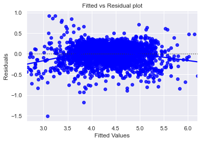

```python
sns.residplot(
    data=df_pred, x="Fitted Values", y="Residuals", color="blue", lowess=True
)


plt.xlabel('Fitted Values')
plt.ylabel('Residuals')
plt.title('Fitted vs Residual plot')
plt.show()
```

We can conclude that the assumption of linearity and independance are satisfied based on the graph above.

1. Test for Normality

Regular hisogram to view distribution

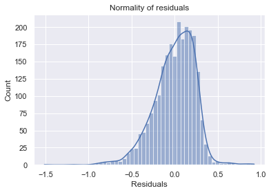

```python
sns.histplot(data=df_pred, x="Residuals", kde=True)
plt.title("Normality of residuals")
plt.show()
```

The QQ Plot below should have a straight line at a 45 degree angle if the distribution is perfectly normal.

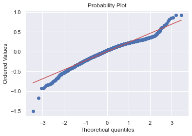

```python
import pylab
import scipy.stats as stats

stats.probplot(df_pred['Residuals'], dist="norm", plot=pylab)
plt.show()
```

Shapiro-Wilk test

```python
stats.shapiro(df_pred['Residuals'])
```

```
ShapiroResult(statistic=0.9676416516304016, pvalue=6.697775553035963e-23)
```

1. Test for Homoscedasticity

We want to ensure there is no clear pattern in the residuals using the goldfeldquandt test.

```python
import statsmodels.stats.api as sms
from statsmodels.compat import lzip

name = ["F statistic", "p-value"]
test = sms.het_goldfeldquandt(df_pred['Residuals'], x_train3)
lzip(name, test)
```

```
[('F statistic', 1.0078188298550237), ('p-value', 0.44649832248119464)]
```

A p-value > 0.05 indicates to us that the model is homoscedastic, therefore satisfying the requirement

## Final Model

```python
x_train_final = x_train3.copy() #save copy of df
x_test_final = x_test3.copy()
```

```python
olsmodel_final = sm.OLS(y_train, x_train_final).fit()
print(olsmodel_final.summary())
```

```
                              OLS Regression Results
=================================================================================
Dep. Variable:     normalized_used_price   R-squared:                       0.839
Model:                               OLS   Adj. R-squared:                  0.838
Method:                    Least Squares   F-statistic:                     896.0
Date:                   Fri, 08 Jul 2022   Prob (F-statistic):               0.00
Time:                           14:33:29   Log-Likelihood:                 81.046
No. Observations:                   2417   AIC:                            -132.1
Df Residuals:                       2402   BIC:                            -45.24
Df Model:                             14
Covariance Type:               nonrobust
========================================================================================
                           coef    std err          t      P>|t|      [0.025      0.975]
----------------------------------------------------------------------------------------
const                    1.4996      0.048     30.951      0.000       1.405       1.595
main_camera_mp           0.0210      0.001     14.716      0.000       0.018       0.024
selfie_camera_mp         0.0138      0.001     12.853      0.000       0.012       0.016
ram                      0.0212      0.005      4.246      0.000       0.011       0.031
weight                   0.0017      6e-05     27.684      0.000       0.002       0.002
normalized_new_price     0.4412      0.011     39.311      0.000       0.419       0.463
years_since_release     -0.0292      0.003     -8.587      0.000      -0.036      -0.022
brand_name_Karbonn       0.1157      0.055      2.114      0.035       0.008       0.223
brand_name_Samsung      -0.0374      0.016     -2.270      0.023      -0.070      -0.005
brand_name_Sony         -0.0670      0.030     -2.197      0.028      -0.127      -0.007
brand_name_Xiaomi        0.0800      0.026      3.113      0.002       0.030       0.130
os_Others               -0.1282      0.027     -4.706      0.000      -0.182      -0.075
os_iOS                  -0.0898      0.045     -1.990      0.047      -0.178      -0.001
4g_yes                   0.0504      0.015      3.340      0.001       0.021       0.080
5g_yes                  -0.0684      0.031     -2.234      0.026      -0.129      -0.008
==============================================================================
Omnibus:                      245.617   Durbin-Watson:                   1.903
Prob(Omnibus):                  0.000   Jarque-Bera (JB):              483.665
Skew:                          -0.656   Prob(JB):                    9.41e-106
Kurtosis:                       4.755   Cond. No.                     2.39e+03
==============================================================================

Notes:
[1] Standard Errors assume that the covariance matrix of the errors is correctly specified.
[2] The condition number is large, 2.39e+03. This might indicate that there are
strong multicollinearity or other numerical problems.
```

```python
#checking model performance on train set (seen 70%)
print("Training Performance")
olsmodel_final_train_perf = model_performance_regression(
    olsmodel_final, x_train_final, y_train
)
olsmodel_final_train_perf
```

```
Training Performance
```

|  | RMSE | MAE | R-squared | Adj. R-squared | MAPE |
| --- | --- | --- | --- | --- | --- |
| 0 | 0.233992 | 0.182732 | 0.839293 | 0.838289 | 4.394792 |

```python
#checking model performance on test set (seen 30%)
print("Test Performance")
olsmodel_final_test_perf = model_performance_regression(
    olsmodel_final, x_test_final, y_test
)
olsmodel_final_test_perf
```

```
Test Performance
```

|  | RMSE | MAE | R-squared | Adj. R-squared | MAPE |
| --- | --- | --- | --- | --- | --- |
| 0 | 0.241525 | 0.186752 | 0.838266 | 0.835889 | 4.55965 |

## Actionable Insights and Recommendations

- Per the final Adj. R-squared of 0.84, our model is explaining about 84% of the variation in the data. Likewise, the MAPE of 4.6 indicates this model can predict the normalized used device price within 4.6%.

#### Knowledge from Coefficients

We can reference the coeffecients in our model summary to see what impact certain features have on the price of the used phones

A single unit increase the price of new phone will result in a posive increase between .419 and 463, provided all other variables are held constant

Likewise, a one unit increase in RAM would results in .0212 increase in the price of a used phone

A one unit increase in the megapixels of the main camera and selfie cameria would return a price increase of .0210 and .0138 respectively

Not surprisingly, a one unit increase in the years since original release will yield a decrease in used phone price between .036 and .022

#### Other notable facts

The negative SKEW in the model output supports our EDA findings that the distribution of used phone prices is negatively SKEWED.

At a glance, we can tell 14 parameters were considered given the 'DF model' being equal to 14

A 'Df Residuals of 2402 represents our number of observations minus number of predicting variables minus 1. In this scenario (2417 - 14 - 1)'

The T-statistic is a quick way to gather which parameters measured high coefficients with low standard error. i.e which parameters are good variables. In order, our most significant were Normalized new price, weight, Main Camera, selfie camera, and years since release